# Analysis of Learning 2014 Database

Jussi Jaatinen

# Analysis of Learning 2014 Database

###### The data has been collected in query about teaching and learning after the course of “Introduction to statistics for social science”“, fall 2014. The most essential parts of study (Deep, Surface and Strategic learning) have been named and combined so, that connection to the thought dimensions can be seen.

##### Summary of dataset.

###### There were twice as much females than men in answer group. Dataset has 166 observations and 7 variables.

```
##  gender       Age           Attitude          deep            stra
##  F:110   Min.   :17.00   Min.   :1.400   Min.   :1.583   Min.   :1.250
##  M: 56   1st Qu.:21.00   1st Qu.:2.600   1st Qu.:3.333   1st Qu.:2.625
##          Median :22.00   Median :3.200   Median :3.667   Median :3.188
##          Mean   :25.51   Mean   :3.143   Mean   :3.680   Mean   :3.121
##          3rd Qu.:27.00   3rd Qu.:3.700   3rd Qu.:4.083   3rd Qu.:3.625
##          Max.   :55.00   Max.   :5.000   Max.   :4.917   Max.   :5.000
##       surf           Points
##  Min.   :1.583   Min.   : 7.00
##  1st Qu.:2.417   1st Qu.:19.00
##  Median :2.833   Median :23.00
##  Mean   :2.787   Mean   :22.72
##  3rd Qu.:3.167   3rd Qu.:27.75
##  Max.   :4.333   Max.   :33.00
```

```
## 'data.frame':    166 obs. of  7 variables:
##  $ gender  : Factor w/ 2 levels "F","M": 1 2 1 2 2 1 2 1 2 1 ...
##  $ Age     : int  53 55 49 53 49 38 50 37 37 42 ...
##  $ Attitude: num  3.7 3.1 2.5 3.5 3.7 3.8 3.5 2.9 3.8 2.1 ...
##  $ deep    : num  3.58 2.92 3.5 3.5 3.67 ...
##  $ stra    : num  3.38 2.75 3.62 3.12 3.62 ...
##  $ surf    : num  2.58 3.17 2.25 2.25 2.83 ...
##  $ Points  : int  25 12 24 10 22 21 21 31 24 26 ...
```

##### Correlations between variables.

###### Due to largest correlation with dependent variable “Points”, three variables were chosen to the model. The independent variables were *Attitude* (R=0.44), *Strategic learning* (R=0.15) and *Surface Learning* (R=-0.14). Genders were combined in correlation test.

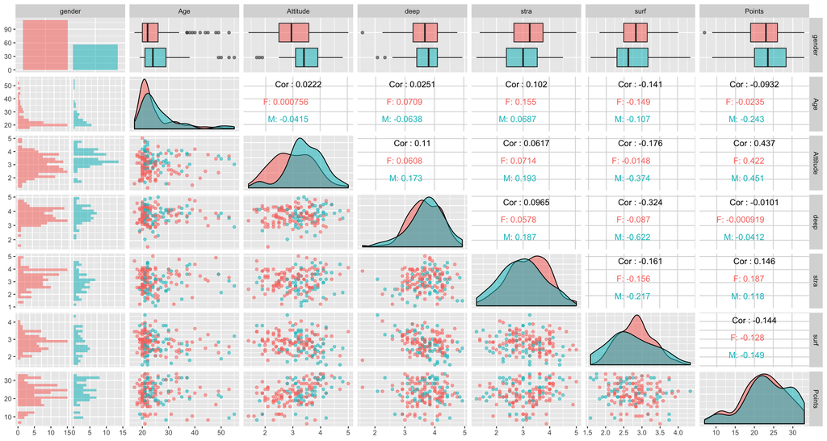

##### For testing, which contributions of chosen independent variables were significant, several possible alternatives were evaluated for the best regression model.

```
##
## Call:
## lm(formula = learning2014$Points ~ learning2014$Attitude + learning2014$stra +
##     learning2014$surf, data = learning2014)
##
## Residuals:
##      Min       1Q   Median       3Q      Max
## -17.1550  -3.4346   0.5156   3.6401  10.8952
##
## Coefficients:
##                       Estimate Std. Error t value Pr(>|t|)
## (Intercept)            11.0171     3.6837   2.991  0.00322 **
## learning2014$Attitude   3.3952     0.5741   5.913 1.93e-08 ***
## learning2014$stra       0.8531     0.5416   1.575  0.11716
## learning2014$surf      -0.5861     0.8014  -0.731  0.46563
## ---
## Signif. codes:  0 '***' 0.001 '**' 0.01 '*' 0.05 '.' 0.1 ' ' 1
##
## Residual standard error: 5.296 on 162 degrees of freedom
## Multiple R-squared:  0.2074, Adjusted R-squared:  0.1927
## F-statistic: 14.13 on 3 and 162 DF,  p-value: 3.156e-08
```

```
##
## Call:
## lm(formula = learning2014$Points ~ learning2014$Attitude + learning2014$stra,
##     data = learning2014)
##
## Residuals:
##      Min       1Q   Median       3Q      Max
## -17.6436  -3.3113   0.5575   3.7928  10.9295
##
## Coefficients:
##                       Estimate Std. Error t value Pr(>|t|)
## (Intercept)             8.9729     2.3959   3.745  0.00025 ***
## learning2014$Attitude   3.4658     0.5652   6.132 6.31e-09 ***
## learning2014$stra       0.9137     0.5345   1.709  0.08927 .
## ---
## Signif. codes:  0 '***' 0.001 '**' 0.01 '*' 0.05 '.' 0.1 ' ' 1
##
## Residual standard error: 5.289 on 163 degrees of freedom
## Multiple R-squared:  0.2048, Adjusted R-squared:  0.1951
## F-statistic: 20.99 on 2 and 163 DF,  p-value: 7.734e-09
```

```
##
## Call:
## lm(formula = learning2014$Points ~ learning2014$Attitude + learning2014$surf,
##     data = learning2014)
##
## Residuals:
##     Min      1Q  Median      3Q     Max
## -17.277  -3.236   0.386   3.977  10.642
##
## Coefficients:
##                       Estimate Std. Error t value Pr(>|t|)
## (Intercept)            14.1196     3.1271   4.515 1.21e-05 ***
## learning2014$Attitude   3.4264     0.5764   5.944 1.63e-08 ***
## learning2014$surf      -0.7790     0.7956  -0.979    0.329
## ---
## Signif. codes:  0 '***' 0.001 '**' 0.01 '*' 0.05 '.' 0.1 ' ' 1
##
## Residual standard error: 5.32 on 163 degrees of freedom
## Multiple R-squared:  0.1953, Adjusted R-squared:  0.1854
## F-statistic: 19.78 on 2 and 163 DF,  p-value: 2.041e-08
```

```
##
## Call:
## lm(formula = learning2014$Points ~ learning2014$Attitude + learning2014$stra +
##     learning2014$gender, data = learning2014)
##
## Residuals:
##      Min       1Q   Median       3Q      Max
## -17.7179  -3.3285   0.5343   3.7412  10.9007
##
## Coefficients:
##                       Estimate Std. Error t value Pr(>|t|)
## (Intercept)             8.9798     2.4030   3.737 0.000258 ***
## learning2014$Attitude   3.5100     0.5956   5.893 2.13e-08 ***
## learning2014$stra       0.8911     0.5441   1.638 0.103419
## learning2014$genderM   -0.2236     0.9248  -0.242 0.809231
## ---
## Signif. codes:  0 '***' 0.001 '**' 0.01 '*' 0.05 '.' 0.1 ' ' 1
##
## Residual standard error: 5.304 on 162 degrees of freedom
## Multiple R-squared:  0.2051, Adjusted R-squared:  0.1904
## F-statistic: 13.93 on 3 and 162 DF,  p-value: 3.982e-08
```

```
##
## Call:
## lm(formula = learning2014$Points ~ learning2014$Attitude, data = learning2014)
##
## Residuals:
##      Min       1Q   Median       3Q      Max
## -16.9763  -3.2119   0.4339   4.1534  10.6645
##
## Coefficients:
##                       Estimate Std. Error t value Pr(>|t|)
## (Intercept)            11.6372     1.8303   6.358 1.95e-09 ***
## learning2014$Attitude   3.5255     0.5674   6.214 4.12e-09 ***
## ---
## Signif. codes:  0 '***' 0.001 '**' 0.01 '*' 0.05 '.' 0.1 ' ' 1
##
## Residual standard error: 5.32 on 164 degrees of freedom
## Multiple R-squared:  0.1906, Adjusted R-squared:  0.1856
## F-statistic: 38.61 on 1 and 164 DF,  p-value: 4.119e-09
```

##### As seen above, only *Attitude* was statistically significant of chosen variables.

##### If comparing R squared (R<sup>2</sup>) values between models, it can be seen that Attitude variable alone explains almost as large amount of variance as if combined with other two of tested variable.

##### For testing validity of model and assumption of normal distributed samples following tests have been done: Residuals vs Fitted, Normal Q-Q and Residuals vs Leverage. As we can see in Residuals vs Fitted, residuals are reasonable normally distributed. In Normal Q-Q plot we can see that residuals follow linearity well enough (except far ends). In Residual vs Leverage image there are no outliers in isolated positions far from mean. Therefore assumption of linearity and normal distribution can be accepted.

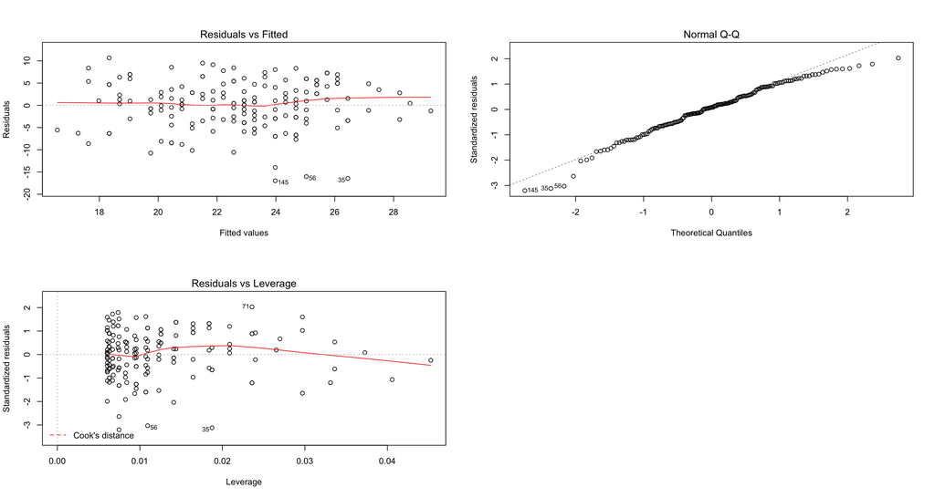

***